# Class 2: Social Movement Theories

Collective behaviour, resource mobilisation, political processes

[Dr. Michael C. Zeller](https://michaelzeller.de)

# Opening notes

[Open Sticker](https://tenor.com/view/open-gif-14209777)from [Open Stickers](https://tenor.com/search/open-stickers)

## Syllabus reading check

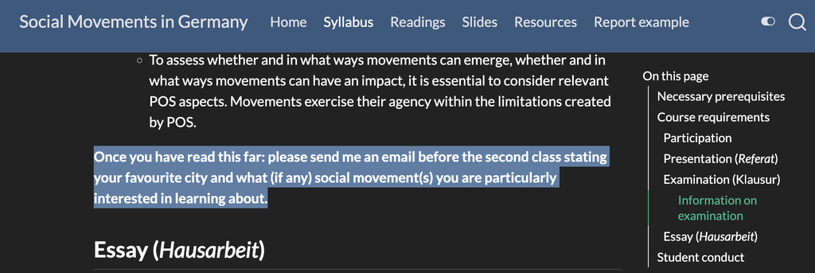

## Students’ favourite cities

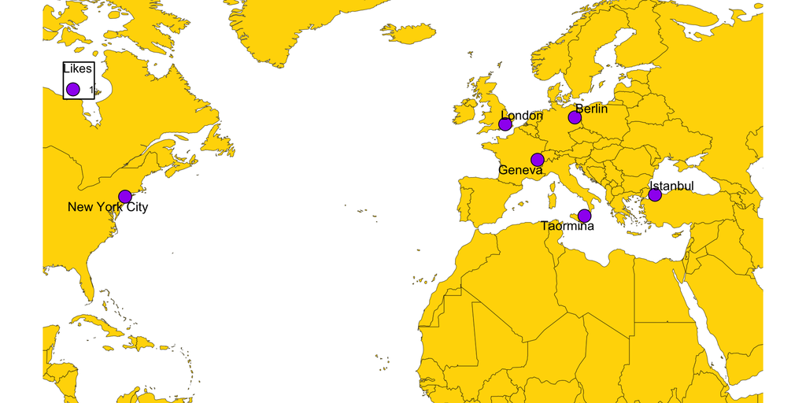

## Presentation groups

Remember: topic to me at least by Week 4

- December
- January

Presentations line-up

| Date | Presenters | Method |
| --- | --- | --- |
| 7 Dec: |  | TBD |
| 14 Dec: |  | TBD |
| 21 Dec: |  | TBD |

Presentations line-up

| Date | Presenters | Method |
| --- | --- | --- |
| 11 Jan: |  | TBD |
| 18 Jan: |  | TBD |
| 25 Jan: |  | TBD |

# Reviewing prominent social movement theories

- Collective behaviour theory
- Resource mobilisation theory
- Political process theory

[Quotation Marks Chris Farley GIF](https://tenor.com/view/quotation-marks-chris-farley-air-quotes-supposedly-quote-gif-18582444)from [Quotation Marks GIFs](https://tenor.com/search/quotation+marks-gifs)

## Collective behaviour theory (CBT)

fundamental question: **why is this *thing* happening?**

- reckoning with legacy of interwar era:
  - why was their the national socialist movement?
  - why was their the Bolshevik revolution?
  - why did people join such movements instead of participating in ‘institutional politics’?

## Collective behaviour theory (CBT)

fundamental question: **why is this *thing* happening?**

- a mix of sociological and psychological approach—influenced by Durkheim and Marx
- movements as consequences and manifestations of strain, deprivation, and grievance
  - movements are ‘abnormal’ (contrary to idea of ‘movement society’)
- movements as part of ‘emergent phenomena,’ ranging from trends and gossip, to collective action, up to and including insurrection and revolution

## Collective behaviour theory (CBT)

fundamental question: **why is this *thing* happening?**

- CBT struggles to predict (Piazza 2017): not everyone is *aggrieved* engages in collective action
  - BUT several core concepts—grievance, (relative) deprivation—endure (e.g., van Stekelenburg and Klandermans 2013 on the social psychology of protest)
    - Because… even if they are neither necessary nor solely sufficient, CBT concepts refer to *important motivations for many movement participants*

## Resource mobilisation theory (RMT)

fundamental question: **how is this *thing* happening?**

- focus on organisations: how they **mobilise** and **campaign** in **strategic** pursuit of goals

*Types of resources*:

- material (finances, property, supplies),
- human (quantity and expert quality of members/activists),
- organisational (capacity to disseminate and enact strategy),
- moral (solidarity support, legitimacy and sympathetic support)
- others?

## Resource mobilisation theory (RMT)

fundamental question: **how is this *thing* happening?**

- RMT rejects the CBT idea that movements are abnormal
- Still, focus on organisations omits/obscures *contextual* factors
- But organisation, strategy, leadership, resources remain important—but better understood with context (e.g., Guzman-Concha 2015; Kern, Marien, and Hooghe 2015; Williamson, Trump, and Einstein 2018)

## Political process theory (PPT)

fundamental question: **what makes/shapes this *thing* that is happening?**

- situates RMT organisational focus within wider socio-political context
- movements are products of the political environment in which they emerge, responding to socio-political changes (**opportunity/threat**) and being met with (broadly) facilitation or repression (Tarrow 2011) (or disregard)

## Political process theory (PPT) - POS concept

fundamental question: **what makes/shapes this *thing* that is happening?**

- key concept: **political opportunity structure**

> “are comprised of specific configurations of resources, institutional arrangements and historical precedents for social mobilisation, which facilitate the development of protest movements in some instances and constrain them in others” (Kitschelt 1986, 58)

## Political process theory (PPT) - DOS concept

fundamental question: **what makes/shapes this *thing* that is happening?**

- related to POS: discursive opportunity structure (Koopmans and Olzak 2004, 202–5): *aspects of the public discourse that determine a message’s chances of diffusion in the public sphere*

## Political process theory (PPT) - DOS concept

discursive opportunity structure (Koopmans and Olzak 2004, 202–5): *aspects of the public discourse that determine a message’s chances of diffusion in the public sphere*

| Discursive opportunity | Description |
| --- | --- |
| Visibility | in public sphere, messages > available space (thus, competition) |
|  | claim makers aim to get messages into public discourse |
|  | gatekeepers select, shape, amplify, or diminish messages |
|  | Is the message visible? - a necessary condition to influence discourse |
| Resonance | Does the message provoke reactions from others in public sphere? |
|  | Is the message supported? (consonance) --- Is the message opposed? (dissonance) (either can help replicate the message) |
| Legitimacy | to what degree is the message supported (vs. opposed) in the public sphere? |
|  | highly legitimate messages may have no resonance at all because they are uncontroversial, while highly illegitimate messages may have strong resonance |

## More on social movement theories next week

- we will cover framing and civil society
- other theories/approaches that we will *not* cover: constructivist approaches; ‘new social movements’; political mediation model; field theory; relational/network approaches
  - though we may encounter these in some of the readings

# Political Opportunity Structures studies

- Kitschelt (1986)
  - research justification
  - case selection
    - comparative case design
  - POS components and effects
- Boudreau (1996)
  - historical development
  - select observations

[Knock Knock Open The Door GIF](https://tenor.com/view/knock-knock-open-the-door-jack-nicholson-the-shining-trendizisst-gif-16467703458233675055)from [Knock Knock GIFs](https://tenor.com/search/knock+knock-gifs)

## Kitschelt (1986) - research justification

POS: *Astra inclinant, sed non obligant.* (‘The stars incline us, they do not bind us.’)

- translation (from Kitschelt 1986):

> While they do not determine the course of social movements completely, careful comparisons among them can explain a good deal about the variations among social movements with similar demands in different settings, if other determinants are held constant.

*In a nutshell, this is what Kitschelt sets out to test*

## Kitschelt (1986) - case selection

- anti-nuclear movements in France, Sweden, US, W. Germany. Why?
- all share similar objective
- similar organisational origins (local, 1970s)
- similar contextual origins (same ‘threat’ of nuclear power in each)
- similar mobilisation sources (‘middle-class radicalism’)
- BUT: different political/institutional contexts
  - open/closed political input structures; strong/weak political output structures
- what do we call this type of case selection strategy?

## Comparative case selection

x = causal variable; y = phenomenon to be explained

MDSD (most different systems design)

| Case 1 | Case 2 | _ |
| --- | --- | --- |
| a | d | overall |
| b | e | differences |
| c | f |  |
| x | x | crucial |
| y | y | similarity |

MSSD (most similar systems design)

| Case 1 | Case 2 | _ |
| --- | --- | --- |
| a | a | overall |
| b | b | similiarities |
| c | c |  |
| x | not x | crucial |
| y | not y | difference |

Further on case selection strategies, see Gerring (2007, e.g., pp. 89-90)

## Kitschelt (1986) - 3 POS effect on movements

1. What resources (‘coercive, normative, remunerative and informational’) can an emergent movement draw upon?
   - note the improvement on RMT, resources depend on context
2. How can movements access the public sphere and political decision-making? (what laws regulate such access)
3. Are there other movements that model (and ease) mobilisation and movement emergence?

## Kitschelt (1986) - POS components

Kitschelt highlights to components of POS relevant to the movements he studies: (1) political input structures and (2) policy implementation capacity

**This is part of *concept formation***

## Concept formation - Adcock and Collier (2001, 531)

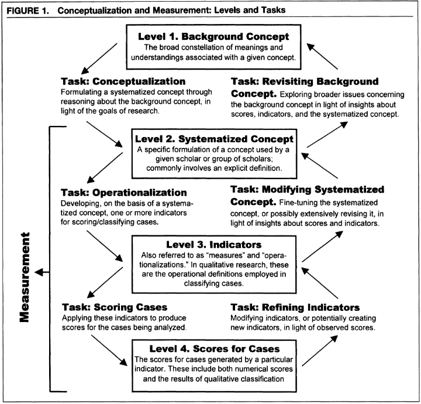

## Kitschelt (1986) - POS components

1. political input structures
   1. number of parties/electoral influences (more = more open)
   2. legislative policy control (more = more open)
   3. accessibility of executive to interest groups (more = more open)
   4. mechanisms to aggregate demands and build policy coalitions (more = more open)
2. policy implementation capacity
   1. state apparatus centralisation (more = stronger effective implementation)
   2. government control over market (more = stronger effective implementation)
   3. independence of the judiciary (more = weaker effective implementation)

## Kitschelt (1986) - case differences

| _ |  | Political input structures | Political input structures |
| --- | --- | --- | --- |
|  |  | Open and responsive | Closed and unresponsive |
| Policy implementation capacity | Weak | United States | West Germany |
|  | Strong | Sweden | France |

- (relatively) open and responsive input structures (Sweden, U.S.) = possibility to impact policy
  - (relatively) closed insisted on pre-determined policies
- Weak implementation capacity offers opportunity for disruption
- Strong implementation capacity could shield policy from attacks

## Kitschelt (1986) - hypotheses

[output not shown]

## Kitschelt (1986) - anti-nuclear strategies

|  | Assimilative strategies aimed at political inputs Lobbying/ petitioning | Assimilative strategies aimed at political inputs Elections/ referendums | Assimilative strategies aimed at political outputs Interventions in licencsing | Assimilative strategies aimed at political outputs Litigation in courts | Confrontational strategies against process Demonstration, disobedience |
| --- | --- | --- | --- | --- | --- |
| United States | high | high | high | high | low |
| Sweden | high | high | low | low | medium |
| West Germany | low | low (later: high) | high | high | high |
| France | low | low (later: high) | low | low | high |

## Kitschelt (1986) - procedural and substantive impacts

- what procedural impacts did anti-nuclear movements have? what (other) procedural impacts could policy-oriented movements have?
- what substantive impacts did anti-nuclear movements have (that Kitschelt examined)?

## Kitschelt (1986) - findings

- hypotheses generally confirmed
  - Sweden and (to lesser extent) U.S. search for new policies
  - France and (to lesser extent) W. Germany stayed on policy course
  - U.S. and W. Germany movements had chance to disrupt implementation
  - Sweden and France movements had no chance to disrupt implementation

> Theories are fruitful only if they can be applied to cases beyond the ones they were first designed to explain. (p. 84)

## Kitschelt (1986) - key takeaways

- what did you learn from this article?
- POS shapes movements and some movements can shape POS
- concept formation of POS should be specific to a given movement
- even in high stakes policy arenas (e.g., energy politics) movements can have impact

## Boudreau (1996) - set-up

- social science theories (including PPT for social movements) are often developed in the ‘North’
  - theory requires adjustment
- structural (cross-national) (Kitschelt 1986) or time-series (McAdam 1982; Tarrow 2011)
- a dense proposal of how to study any type of movement, anywhere

## Boudreau (1996) - historical development (Tilly)

- state expansion (including improved communication networks, rising middle class, etc.) helps to create an *audience*
  - incentivises demonstrations as collective action repertoire

> seeks to accumulate influence within a political structure, to communicate a demand, convey resolve, and (where the polity is unresponsive) raise the costs of disregarding the movement. … They play to the polity (and to allies) whose subsequent action resolves movement grievances. … *Demonstrations inconvenience or embarrass authorities and establish the movement’s social support but never themselves attain the collective goal*. (p. 181)

## Boudreau (1996) - historical development (Tilly)

- state expansion (including improved communication networks, rising middle class, etc.) helps to create an *audience*
  - direct action repertoires

> seize resources to satisfy their demands or take unilateral action to resolve a grievance. … *Direct action seeks itself to achieve collective goals*. (p. 181)
- in line with Kitschelt (1986), POS shapes mobilisation: ‘closed’ and ‘centralised’ more inviting for direct action; ‘open’ and ‘decentralised’ more inviting for demonstration

## Boudreau (1996, 178)

> SMOs attract mass support by offering more promising avenues (massed demonstration, armed battle, land occupation) to achieve popular goals than existing modes of action

## Boudreau (1996, 177) - sequence for research

- identification of collective repertoires and their relationships to the new cases’ structural environments
  - Political opportunity structure is specific—not general
- how does short-term structural variation encourage mobilisation
- how do differences between differently structured states influence the frequency or intensity of mobilisation

> McAdam’s caution: “[I]t is critical that we be explicit about which dependent variable we are seeking to explain, and which dimensions of political opportunity are germane to that explanation.”
- Two principles (p. 186)
  1. Social/political structures limit possible forms of collective action, thus limiting opportunities
  2. Opportunities influence activity by altering the prospects of different forms of struggle

## Boudreau (1996) - select observations

- Poverty and levels of oppression are fundamental *structural variables* underlying all POS (p. 179) [cf. Piven and Cloward (1979); Scott (1985)]
- Campaigns must win/provide *benefits* or else face increasing demobilising pressure (p. 183) (cf. Gamson 1990; Davenport 2015; Demirel-Pegg 2017; Zeller 2022)
- SM organisations have to weigh trade-offs between demonstration strategies and direct action strategies (p. 184) (cf. Ganz 2010)
- Property of *inertia*: initial conditions surrounding mobilisation powerfully influence on subsequent movement trajectories (p. 185) (cf. Polletta and Jasper 2001)

# Social movements in/around Germany

- open to discussion on all sorts of movements
- highlighting movement organisations to be assigned next week
- introduction of cases

[Germany History GIF](https://tenor.com/view/germany-history-funny-what-whats-happening-gif-17835309)from [Germany GIFs](https://tenor.com/search/germany-gifs)

## All sorts of movements

- case assignment (six possibilities) next week; selected because…
  - were/are active in Germany (most for long periods)
  - have been researched extensively
  - represent a mix of frames and topical focuses
- we will also discuss other cases (e.g., U.S. Civil Rights Movement)
- we can discuss cases you are interested in, just remember:
  - we aim to *analyse* and *understand* movements; we are not here to arbitrate their claims/demands or engage in activism
- some movements involve charged political issues, so remember:
  - treat each other with mutual respect
  - most are working in 2nd/3rd/4th language, so do not assume provocation if you disagree with an expression

## Social movements in/around Germany

> “Those who only know one country, know no country” - Seymour Martin Lipset (inspired by Alexis de Tocqueville)
- well-known and covered in media and research literature
- diverse strategies, objectives, and ideological characteristics
- active in Germany (and elsewhere in the EU)

## Social movements in/around Germany

*Federation of Antifascists* (VVN-BdA),  
*Fridays for Future* (FFF, climate),  
*Identitarian* (ethno-pluralism),  
*Letzte Generation* (LG, climate),  
*PEGIDA* (ethno-pluralism),  
*Querdenken 711* (anti-vaccination/lockdown),

## Federation of Antifascists (VVN-BdA)

‘*Vereinigung der Verfolgten des Naziregimes – Bund der Antifaschistinnen und Antifaschisten*’

- Issue: anti-fascism
- Active: 1947-present
- Membership: large
- Repertoire of actions: politics of memory work, transitional justice advocacy, demonstrations

[figure not shown]

## Fridays for Future

- Issue: climate change
- Active: 2010s-present
- Membership: large
- Repertoire of actions: demonstrations/‘strikes’, disruptive actions, policy processes

[figure not shown]

## Identitarians

- Issue: European ethno-cultural identity
- Active: 2000s-present
- Membership: moderate
- Repertoire of actions: symbolic (social media) protest, demonstrations, transnational

[figure not shown]

## Letzte Generation

- Issue: climate change
- Active: 2021-present
- Membership: moderate, quite professionalised
- Repertoire of actions: disruptive actions/blockades, symbolic protest, demonstrations

[figure not shown]

## PEGIDA

- Issue: German ethno-cultural identity
- Active: 2014-2024
- Membership: moderate
- Repertoire of actions: demonstrations

[figure not shown]

## Querdenken 711

- Issue: COVID-19 policy
- Active: 2020-2022
- Membership: moderate
- Repertoire of actions: civil disobedience, demonstrations, symbolic protest

[figure not shown]

# Any questions, concerns, feedback for this class?

Anonymous feedback here: https://forms.gle/AjHt6fcnwZxkSg4X8

Alternatively, please send me an email: m.zeller@lmu.de

## References

Adcock, Robert, and David Collier. 2001. “Measurement Validity: A Shared Standard for Qualitative and Quantitative Research.” *American Political Science Review* 95 (3): 529–46. https://doi.org/10.1017/S0003055401003100.

Boudreau, Vincent. 1996. “Northern Theory, Southern Protest: Opportunity Structure Analysis in Cross-National Perspective.” *Mobilization* 1 (2): 175–89.

Davenport, Christian. 2015. *How Social Movements Die*. Cambridge: Cambridge University Press. https://doi.org/10.1017/cbo9781139649728.

Demirel-Pegg, Tijen. 2017. “The Dynamics of the Demobilization of the Protest Campaign in Assam.” *International Interactions* 43 (2): 175–216. https://doi.org/10.1080/03050629.2016.1128430.

Gamson, William A. 1990. *The Strategy of Social Protest*. Belmont: Wadsworth Publishing.

Ganz, Marshall. 2010. *Why David Sometimes Wins: Leadership, Organization, and Strategy in the California Farm Worker Movement*. Oxford: Oxford University Press.

Gerring, John. 2007. *Case Study Research: Principles and Practices*. Cambridge: Cambridge University Press.

Guzman-Concha, Cesar. 2015. “Radical Social Movements in Western Europe: A Configurational Analysis.” *Social Movement Studies* 14 (6): 668–91. https://doi.org/10.1080/14742837.2014.998644.

Kern, Anna, Sofie Marien, and Marc Hooghe. 2015. “Economic Crisis and Levels of Political Participation in Europe (2002–2010): The Role of Resources and Grievances.” *West European Politics* 38 (3): 465–90. https://doi.org/10.1080/01402382.2014.993152.

Kitschelt, Herbert P. 1986. “Political Opportunity Structures and Political Protest: Anti-Nuclear Movements in Four Democracies.” *British Journal of Political Science* 16 (1): 57–85.

Koopmans, Ruud, and Susan Olzak. 2004. “Discursive Opportunities and the Evolution of Right-Wing Violence in Germany.” *American Journal of Sociology* 110 (1): 198–230. https://doi.org/10.1086/386271.

McAdam, Doug. 1982. *Political Process and the Development of Black Insurgency, 1930-1970*. Chicago: University of Chicago Press.

Piazza, James A. 2017. “The Determinants of Domestic Right-Wing Terrorism in the USA: Economic Grievance, Societal Change and Political Resentment.” *Conflict Management and Peace Science* 34 (1): 52–80. https://doi.org/10.1177/0738894215570429.

Piven, Francis Fox, and Richard A Cloward. 1979. *Poor People’s Movements*. New York: Vintage Books.

Polletta, Francesca, and James M Jasper. 2001. “Collective Identity and Social Movements.” *Annual Review of Sociology* 27 (1): 283–305.

Tarrow, Sidney G. 2011. *Power in Movement: Social Movements and Contentious Politics*. Cambridge: Cambridge University Press. https://doi.org/10.1017/CBO9780511973529.

van Stekelenburg, Jacquelien, and Bert Klandermans. 2013. “The Social Psychology of Protest.” *Current Sociology Review* 61 (5-6): 886–905. https://doi.org/10.1177/0011392113479314.

Williamson, Vanessa, Kris Stella Trump, and Katherine Levine Einstein. 2018. “Black Lives Matter: Evidence That Police-Caused Deaths Predict Protest Activity.” *Perspectives on Politics* 16 (2): 400–415. https://doi.org/10.1017/S1537592717004273.

Zeller, Michael C. 2022. “Demobilising Far-Right Demonstration Campaigns: Coercive Counter-Mobilisation, State Social Control, and the Demobilisation of the Hess Gedenkmarsch Campaign.” *Social Movement Studies* 21 (3): 372–90. https://doi.org/10.1080/14742837.2021.1889493.